# Modelos de regresión generalizados para la estimación de la cantidad de recuperados de la COVID-19

Claudia Quintana Wong

26/2/2021

## Introducción

Según la OMS: “Una importante característica de las enfermedades infecciosas es la gravedad, que en última instancia se mide por su capacidad para causar la muerte”. Por esta razón, este trabajo se centra en la estimación de la cantidad de personas recuperadas en un día en un estado determiando de los Estados Unidos a partir de los datos recogidos hasta el momento.

## Desarrollo

Los modelos lineales generalizados son una extensión de los modelos de regresión lineal que se utilizan cuando la distribución de la variable dependiente no es normal. En este trabajo se presentan un conjunto de modelos de regresión generalizados que intentan explicar y predecir la cantidad de enfermos de COVID recuperados. Se ofrece una breve descripción del conjunto de datos y las variables a tener en cuenta para la estimación y se comparan los modelos propuestos.

### Descripción del *dataset*

Los datos fueron tomados de https://github.com/CSSEGISandData/COVID-19/tree/master/csse_covid_19_data/csse_covid_19_daily_reports_us. Este repositorio contiene información actualizada diariamente sobre el estado de los casos de COBID-19 en el mundo, haciendo especial énfasis en los datos de los Estados Unidos.

Las variables originales son:

Para conformar el dataset tal como lo usaremos fue preciso realizar un preprocesamiento. La fuente de datos no era un archivo en formato de tabla inicialmente, sino que consistía en un directorio donde había archivos .csv individuales con los datos de cada día. Fue necesario leer todos los archivos y mezclar toda la información. Además, esto supuso un trabajo de limpieza de los datos puesto que todos los archivos no tenían las mismas columnas. Luego de unir toda la información se exportó a un archivo csv donde se almacena el histórico de todos los datos relacionados con los casos en los Estados Unidos.

### Carga y transformación

Primeramente se cargan los datos y se transforman las variables que expresan una fecha.

```r
data <- read.csv(file = 'data/covid_data_us.csv')
data$Last_Update <- as.Date(data$Last_Update)
data$Date <- as.Date(data$Date)
summary(data)
```

```
##  Province_State     Country_Region      Last_Update              Lat
##  Length:16524       Length:16524       Min.   :2020-04-12   Min.   :21.09
##  Class :character   Class :character   1st Qu.:2020-07-02   1st Qu.:35.63
##  Mode  :character   Mode  :character   Median :2020-09-21   Median :39.85
##                                        Mean   :2020-09-21   Mean   :39.46
##                                        3rd Qu.:2020-12-11   3rd Qu.:43.33
##                                        Max.   :2021-03-02   Max.   :61.37
##
##      Long_           Confirmed           Deaths        Recovered
##  Min.   :-157.50   Min.   :    270   Min.   :    0   Min.   :      0
##  1st Qu.:-105.31   1st Qu.:  18194   1st Qu.:  426   1st Qu.:   5282
##  Median : -89.62   Median :  75052   Median : 1657   Median :  21360
##  Mean   : -93.34   Mean   : 195987   Mean   : 4400   Mean   :  89513
##  3rd Qu.: -78.17   3rd Qu.: 225076   3rd Qu.: 5146   3rd Qu.:  89737
##  Max.   : -69.38   Max.   :3573549   Max.   :52491   Max.   :2429453
##                                                      NA's   :2758
##      Active             FIPS       Incident_Rate      Total_Test_Results
##  Min.   :   -989   Min.   : 1.00   Min.   :   32.77   Min.   :    5459
##  1st Qu.:   6438   1st Qu.:16.00   1st Qu.:  633.02   1st Qu.:  283982
##  Median :  24522   Median :29.00   Median : 1849.91   Median :  944332
##  Mean   : 116497   Mean   :28.96   Mean   : 3010.12   Mean   : 2490887
##  3rd Qu.:  99359   3rd Qu.:42.00   3rd Qu.: 4582.29   3rd Qu.: 2671500
##  Max.   :3521058   Max.   :56.00   Max.   :13102.87   Max.   :48712676
##
##  People_Hospitalized Case_Fatality_Ratio      UID              ISO3
##  Min.   :   10.0     Min.   :0.000       Min.   :8.4e+07   Length:16524
##  1st Qu.:  587.2     1st Qu.:1.435       1st Qu.:8.4e+07   Class :character
##  Median : 2055.0     Median :2.080       Median :8.4e+07   Mode  :character
##  Mean   : 6232.6     Mean   :2.771       Mean   :8.4e+07
##  3rd Qu.: 6111.5     3rd Qu.:3.638       3rd Qu.:8.4e+07
##  Max.   :89995.0     Max.   :9.741       Max.   :8.4e+07
##  NA's   :11462
##   Testing_Rate      Hospitalization_Rate      Date
##  Min.   :   460.3   Min.   : 2.303       Min.   :2020-04-12
##  1st Qu.:  9466.6   1st Qu.: 8.402       1st Qu.:2020-07-01
##  Median : 25421.4   Median :11.355       Median :2020-09-20
##  Mean   : 40593.7   Mean   :12.198       Mean   :2020-09-20
##  3rd Qu.: 60987.3   3rd Qu.:15.382       3rd Qu.:2020-12-10
##  Max.   :284257.3   Max.   :38.501       Max.   :2021-03-01
##                     NA's   :11462
```

Analicemos la distribución de valores desconocidos según las variables.

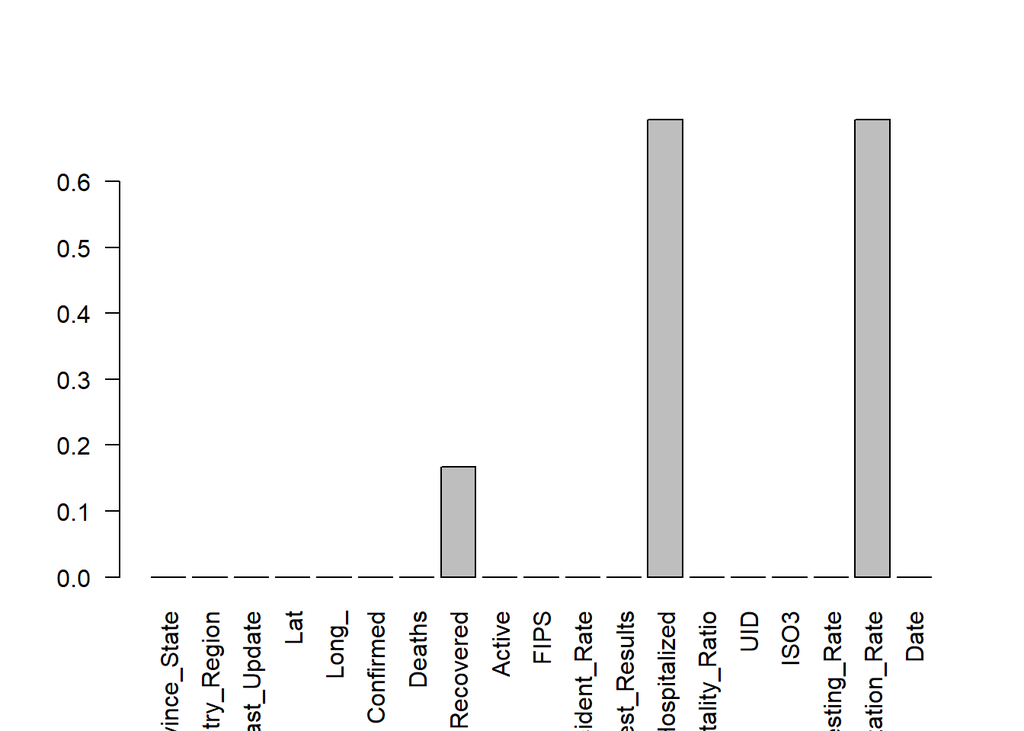

```r
barplot(colMeans(is.na(data)), las=2)
```

```r
data <- na.omit(data)
```

Tras aplicar la eliminación de las filas que contienen valores desconocidos, se puede observar que el conjunto de datos queda libre de *missing values*.

```r
colSums(is.na(data))
```

```
##       Province_State       Country_Region          Last_Update
##                    0                    0                    0
##                  Lat                Long_            Confirmed
##                    0                    0                    0
##               Deaths            Recovered               Active
##                    0                    0                    0
##                 FIPS        Incident_Rate   Total_Test_Results
##                    0                    0                    0
##  People_Hospitalized  Case_Fatality_Ratio                  UID
##                    0                    0                    0
##                 ISO3         Testing_Rate Hospitalization_Rate
##                    0                    0                    0
##                 Date
##                    0
```

En el conjunto de datos hay muchas variales que no aportan información a un modelo de regresión. Por lo tanto, se seleccionan un conjunto de las que se consideran que pudiera ser parte de algunos de los modelos a desarrollar. Además, se toman datos a partir del 1ro de julio de 2020 puesto que los datos son más fiables.

```r
covid.data <- data %>%
  dplyr::select(Province_State, Lat, Long_, Confirmed, Deaths, Recovered, Active, Incident_Rate,
         Total_Test_Results, People_Hospitalized, Case_Fatality_Ratio,
         Testing_Rate, Hospitalization_Rate, Date) %>%
  dplyr::filter(Date >= "2020-07-01") %>%
  dplyr::arrange(Date)
```

### Análisis descriptivo

Comenzaremos con un análisis de la distribución de la variable objetivo.

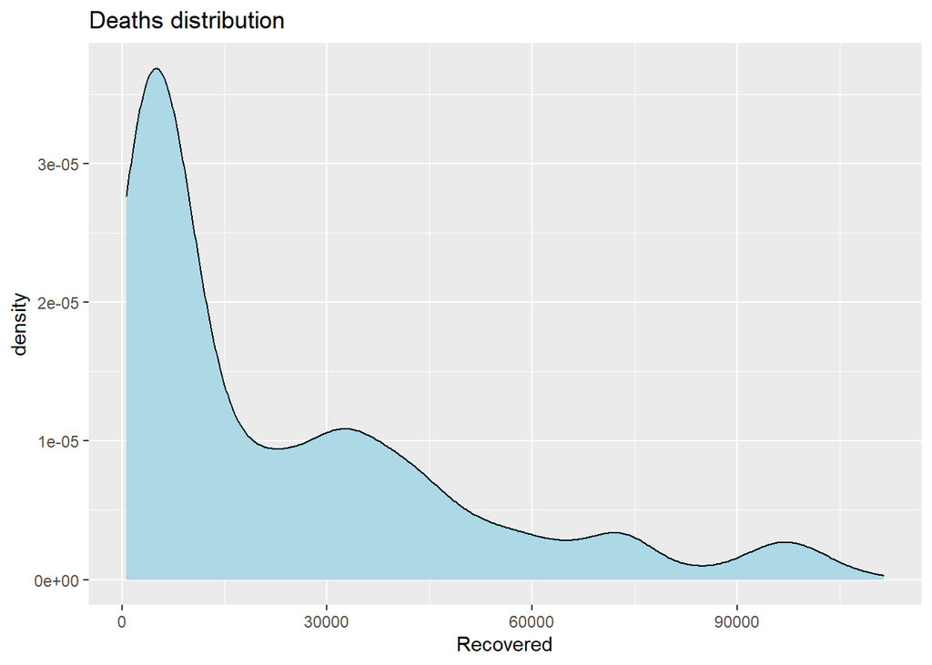

```r
ggplot(covid.data, aes(Recovered)) + geom_density(fill="lightblue") +
  xlab("Recovered") + ggtitle("Deaths distribution")
```

En la gráfica anterior se puede observar que la mayor cantidad de recuperados está en el rango de 0 a 15.000 diariamente. La función de distribución de la variable objetivo sugiere que la mejor manera de predecir ese comportamiento es mediante una función exponencial. Apliquemos la función logaritmo.

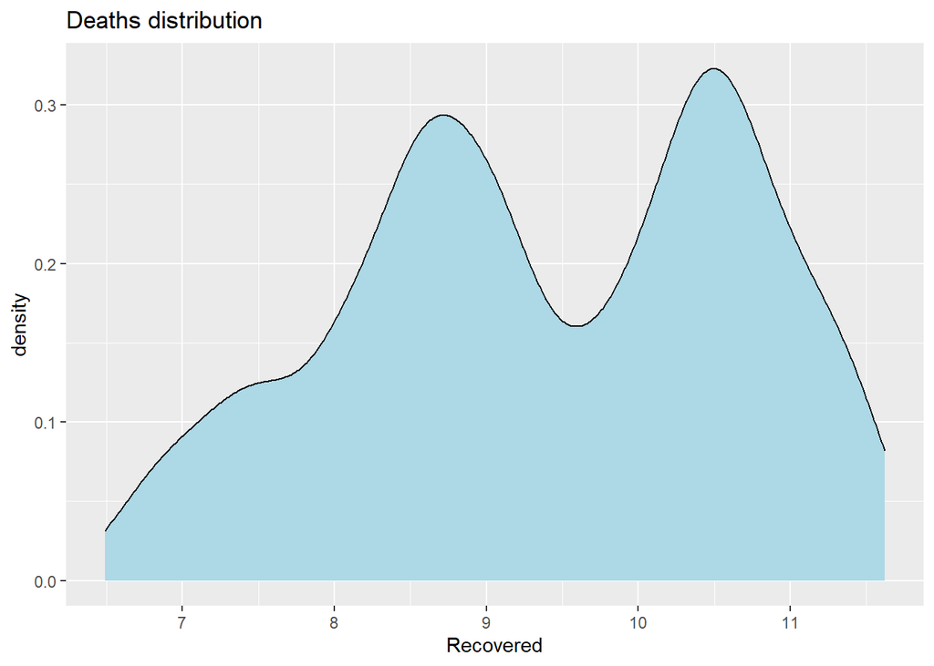

```r
ggplot(covid.data, aes(x= log(Recovered))) + geom_density(fill="lightblue") +
  xlab("Recovered") + ggtitle("Deaths distribution")
```

La función de densidad sobre el logaritmo de la variable dependiente sugiere que, aunque no tiene un patrón lineal, una línea puede ajustarse mejor a esta distribución que a la densidad de la variable dependiente en bruto. Aunque tambiés en posible afirmar que un modelo lineal no es el mejor para simular el comportamiento de esta variable.

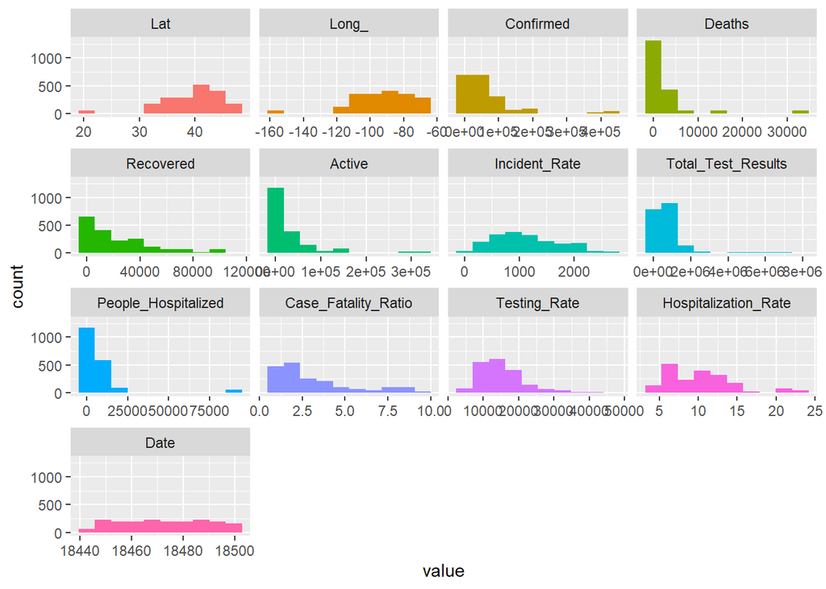

```r
plot_num(covid.data)
```

Analizamos la existencia de valores atípicos. En la siguiente imagen se observa que en la mayor parte de las variables que ofrecen información diaria del COVID aparecen valores más allá de los bigotes de las cajas. Este comportamiento es esperados dado los picos de contagios característicos de la pandemia, por esta razón no serán eliminados.

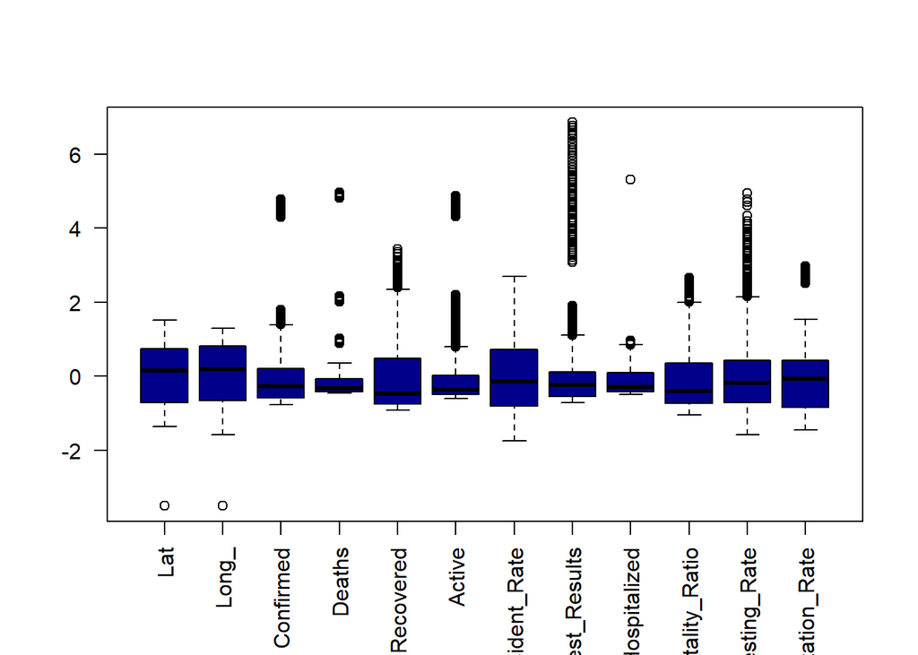

```r
numeric_cols = sapply(covid.data, is.numeric)
boxplot(scale(covid.data[, numeric_cols]), las=2, col='darkblue')
```

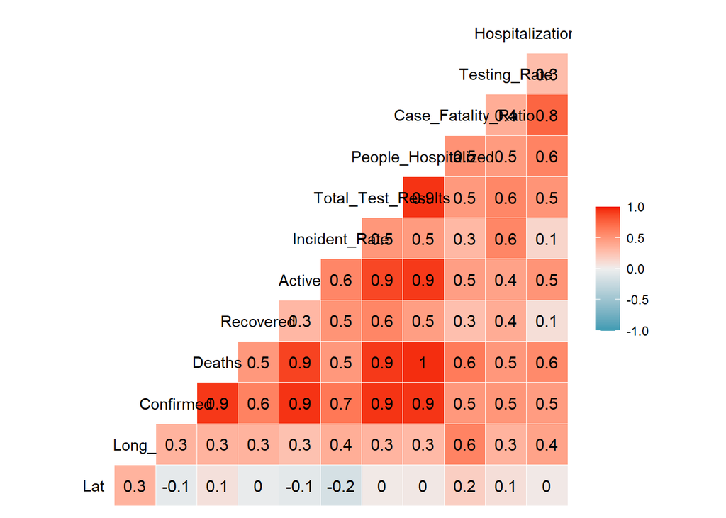

```r
ggcorr(covid.data[,numeric_cols], label = T)
```

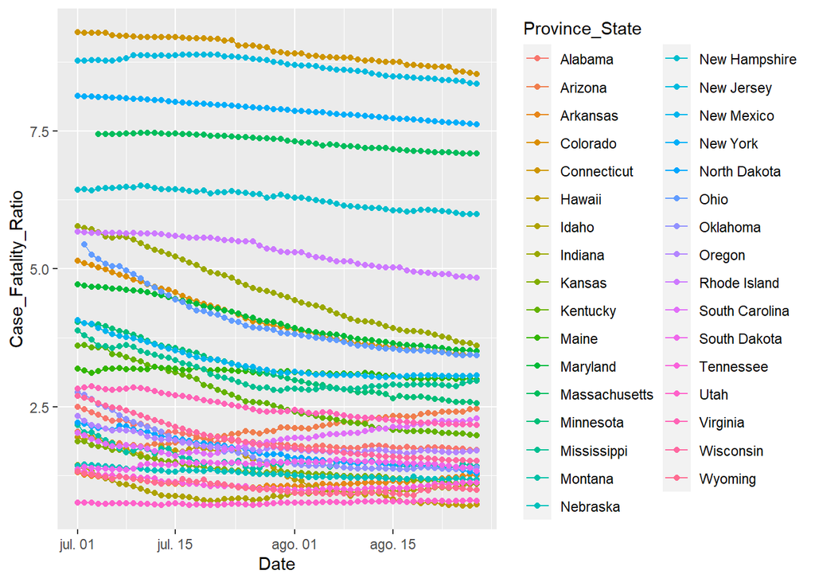

```r
covid.data %>%
  ggplot(aes(x=Date, y=Case_Fatality_Ratio, color = Province_State)) +
  geom_line() +
  geom_point()
```

### Modelo de regresión

La cantidad de recuperados se puede obtener a largo plazo sobre la cantidad de casos activos y la cantidad de fallecidos. Sin embargo, la cantidad de fallecidos en un día no incide directamente sobre la cantidad de recuperados porque generalmente al tiempo que una persona fallece no se habría recuperado ya. Este hecho se detectaría mejor con el análisis de series temporales, pero no es el objetivo de este trabajo.

Para comenzar continuar con el desarrollo de los modelos se divide el conjunto de datos original en *training* y *test* para comprobar las predicciones en nuevos datos.

```r
set.seed(42)

trainIndex <- createDataPartition(c(covid.data$Province_State), p = .7,
                                  list = FALSE,
                                  times = 1)
training <- covid.data[ trainIndex,]
testing <- covid.data[-trainIndex,]
```

En esta sección se aplical modelos de regresión lineal clásicos para comparar las diferencias en interpretabilidad respecto a modelos lineales generalizados más complejos.

### Regresión lineal

Inicialmente, se presenta modelo de regresión lineal con el objetivo de entender la influencia de los predictores sobre la variable objetivo y utilizar dicho conocimiento para desarrollar modelos más complejos y creativos. El primer modelo que se presenta es el modelo en el que la variable objetivo se expresa en función de todas las variables del *dataset*.

- Modelo lineal simple

```r
fit.lm <- lm(Recovered ~ . - Lat - Long_, data=training)
summary(fit.lm)
```

```
##
## Call:
## lm(formula = Recovered ~ . - Lat - Long_, data = training)
##
## Residuals:
##      Min       1Q   Median       3Q      Max
## -1009.72   -23.08    -4.38    21.18   963.12
##
## Coefficients:
##                                Estimate Std. Error   t value Pr(>|t|)
## (Intercept)                   6.725e+04  1.394e+04     4.826 1.56e-06 ***
## Province_StateArizona         2.234e+02  9.428e+01     2.369 0.017969 *
## Province_StateArkansas        3.643e+02  4.428e+01     8.227 4.58e-16 ***
## Province_StateColorado        7.624e+02  6.711e+01    11.361  < 2e-16 ***
## Province_StateConnecticut     1.282e+03  1.690e+02     7.584 6.33e-14 ***
## Province_StateHawaii          6.950e+02  5.821e+01    11.940  < 2e-16 ***
## Province_StateIdaho           3.521e+02  4.944e+01     7.121 1.76e-12 ***
## Province_StateIndiana         8.526e+02  9.261e+01     9.206  < 2e-16 ***
## Province_StateKansas          4.349e+02  4.437e+01     9.803  < 2e-16 ***
## Province_StateKentucky        6.782e+02  5.029e+01    13.484  < 2e-16 ***
## Province_StateMaine           6.914e+02  6.301e+01    10.973  < 2e-16 ***
## Province_StateMaryland        7.712e+02  8.111e+01     9.509  < 2e-16 ***
## Province_StateMassachusetts   1.959e+03  2.841e+02     6.896 8.30e-12 ***
## Province_StateMinnesota       7.138e+02  6.374e+01    11.198  < 2e-16 ***
## Province_StateMississippi     4.442e+02  6.035e+01     7.360 3.23e-13 ***
## Province_StateMontana         6.288e+02  5.281e+01    11.907  < 2e-16 ***
## Province_StateNebraska        3.633e+02  4.715e+01     7.705 2.57e-14 ***
## Province_StateNew Hampshire   6.023e+02  1.259e+02     4.782 1.93e-06 ***
## Province_StateNew Jersey      9.946e+02  5.076e+02     1.959 0.050273 .
## Province_StateNew Mexico      7.028e+02  6.041e+01    11.634  < 2e-16 ***
## Province_StateNew York        5.256e+03  9.640e+02     5.452 5.94e-08 ***
## Province_StateNorth Dakota    5.020e+02  5.385e+01     9.322  < 2e-16 ***
## Province_StateOhio            1.229e+03  1.077e+02    11.407  < 2e-16 ***
## Province_StateOklahoma        5.497e+02  4.338e+01    12.673  < 2e-16 ***
## Province_StateOregon          6.337e+02  5.072e+01    12.494  < 2e-16 ***
## Province_StateRhode Island   -7.774e+02  1.045e+02    -7.441 1.80e-13 ***
## Province_StateSouth Carolina  3.550e+02  4.557e+01     7.789 1.37e-14 ***
## Province_StateSouth Dakota    5.221e+02  5.258e+01     9.930  < 2e-16 ***
## Province_StateTennessee       3.059e+02  5.441e+01     5.621 2.32e-08 ***
## Province_StateUtah            3.636e+02  4.468e+01     8.137 9.37e-16 ***
## Province_StateVirginia        5.500e+02  5.065e+01    10.858  < 2e-16 ***
## Province_StateWisconsin       5.825e+02  4.585e+01    12.707  < 2e-16 ***
## Province_StateWyoming         5.828e+02  5.302e+01    10.993  < 2e-16 ***
## Confirmed                     1.002e+00  1.260e-03   794.769  < 2e-16 ***
## Deaths                       -1.270e+00  4.564e-02   -27.834  < 2e-16 ***
## Active                       -9.985e-01  9.951e-04 -1003.444  < 2e-16 ***
## Incident_Rate                 2.528e-01  5.091e-02     4.967 7.71e-07 ***
## Total_Test_Results           -2.838e-05  2.932e-05    -0.968 0.333205
## People_Hospitalized           3.416e-02  8.756e-03     3.901 0.000101 ***
## Case_Fatality_Ratio           3.051e+01  2.918e+01     1.046 0.295862
## Testing_Rate                 -4.286e-03  2.569e-03    -1.669 0.095433 .
## Hospitalization_Rate         -2.669e+01  8.657e+00    -3.083 0.002090 **
## Date                         -3.669e+00  7.557e-01    -4.855 1.35e-06 ***
## ---
## Signif. codes:  0 '***' 0.001 '**' 0.01 '*' 0.05 '.' 0.1 ' ' 1
##
## Residual standard error: 143 on 1307 degrees of freedom
## Multiple R-squared:      1,  Adjusted R-squared:      1
## F-statistic: 1.028e+06 on 42 and 1307 DF,  p-value: < 2.2e-16
```

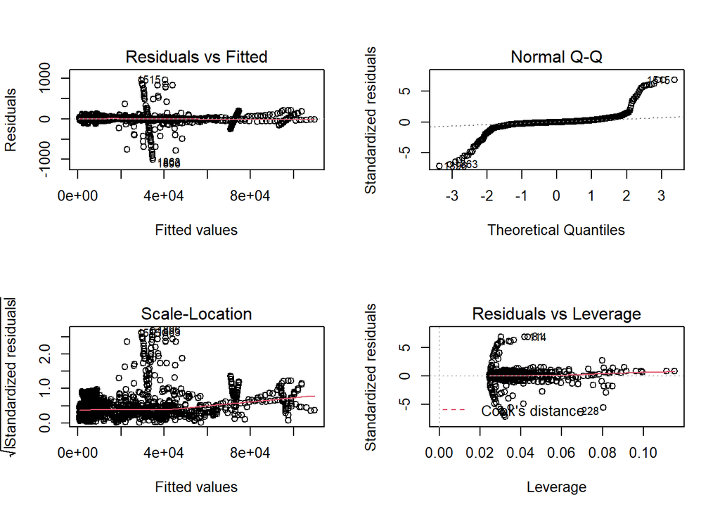

```r
par(mfrow=c(2,2))
plot(fit.lm)
```

A pesar de la simplicidad del modelo lineal, se logra alcanzar un R2 muy alto pero esto solo quiere decir que el modelo esta muy sobre-ajustado y que sería bueno para predecir en el contexto de la regresión lineal. Aunque no se pueda tomar solo este modelo para interpretar los resultados si podemos analizar la influencia indudable de algunas variables.

- Modelo lineal con logaritmo

```r
fit.lm.log <- lm(log(Recovered) ~ .-Lat -Long_, data=training)
summary(fit.lm.log)
```

```
##
## Call:
## lm(formula = log(Recovered) ~ . - Lat - Long_, data = training)
##
## Residuals:
##      Min       1Q   Median       3Q      Max
## -0.58196 -0.04206  0.00662  0.04729  0.54350
##
## Coefficients:
##                                Estimate Std. Error t value Pr(>|t|)
## (Intercept)                  -1.136e+02  1.056e+01 -10.761  < 2e-16 ***
## Province_StateArizona        -1.578e-01  7.144e-02  -2.209  0.02734 *
## Province_StateArkansas       -1.352e-01  3.355e-02  -4.030 5.90e-05 ***
## Province_StateColorado       -1.211e+00  5.085e-02 -23.809  < 2e-16 ***
## Province_StateConnecticut    -1.386e+00  1.281e-01 -10.822  < 2e-16 ***
## Province_StateHawaii         -2.380e+00  4.410e-02 -53.968  < 2e-16 ***
## Province_StateIdaho          -1.666e+00  3.746e-02 -44.487  < 2e-16 ***
## Province_StateIndiana         4.554e-01  7.017e-02   6.490 1.21e-10 ***
## Province_StateKansas         -2.985e+00  3.362e-02 -88.799  < 2e-16 ***
## Province_StateKentucky       -8.009e-01  3.811e-02 -21.016  < 2e-16 ***
## Province_StateMaine          -1.795e+00  4.774e-02 -37.606  < 2e-16 ***
## Province_StateMaryland       -1.255e+00  6.145e-02 -20.424  < 2e-16 ***
## Province_StateMassachusetts   6.036e-01  2.153e-01   2.804  0.00513 **
## Province_StateMinnesota       3.585e-01  4.830e-02   7.424 2.04e-13 ***
## Province_StateMississippi    -5.080e-01  4.573e-02 -11.108  < 2e-16 ***
## Province_StateMontana        -2.289e+00  4.001e-02 -57.200  < 2e-16 ***
## Province_StateNebraska       -6.729e-01  3.573e-02 -18.833  < 2e-16 ***
## Province_StateNew Hampshire  -2.138e+00  9.543e-02 -22.406  < 2e-16 ***
## Province_StateNew Jersey      1.183e+00  3.846e-01   3.077  0.00214 **
## Province_StateNew Mexico     -1.019e+00  4.577e-02 -22.262  < 2e-16 ***
## Province_StateNew York        3.567e+00  7.304e-01   4.884 1.17e-06 ***
## Province_StateNorth Dakota   -1.788e+00  4.080e-02 -43.812  < 2e-16 ***
## Province_StateOhio            1.000e+00  8.162e-02  12.256  < 2e-16 ***
## Province_StateOklahoma        6.483e-02  3.287e-02   1.972  0.04878 *
## Province_StateOregon         -1.437e+00  3.843e-02 -37.404  < 2e-16 ***
## Province_StateRhode Island   -3.811e+00  7.916e-02 -48.151  < 2e-16 ***
## Province_StateSouth Carolina -1.109e-01  3.453e-02  -3.213  0.00135 **
## Province_StateSouth Dakota   -1.127e+00  3.984e-02 -28.292  < 2e-16 ***
## Province_StateTennessee       4.938e-01  4.123e-02  11.976  < 2e-16 ***
## Province_StateUtah           -1.727e-01  3.385e-02  -5.101 3.88e-07 ***
## Province_StateVirginia       -2.068e-01  3.838e-02  -5.388 8.45e-08 ***
## Province_StateWisconsin       4.614e-01  3.474e-02  13.283  < 2e-16 ***
## Province_StateWyoming        -2.260e+00  4.017e-02 -56.250  < 2e-16 ***
## Confirmed                     1.098e-06  9.549e-07   1.149  0.25060
## Deaths                       -2.155e-04  3.458e-05  -6.230 6.26e-10 ***
## Active                       -1.054e-05  7.540e-07 -13.981  < 2e-16 ***
## Incident_Rate                 6.890e-04  3.857e-05  17.863  < 2e-16 ***
## Total_Test_Results           -4.213e-08  2.222e-08  -1.897  0.05811 .
## People_Hospitalized           7.167e-05  6.635e-06  10.802  < 2e-16 ***
## Case_Fatality_Ratio           2.513e-01  2.211e-02  11.369  < 2e-16 ***
## Testing_Rate                  6.368e-07  1.946e-06   0.327  0.74356
## Hospitalization_Rate         -9.587e-02  6.559e-03 -14.616  < 2e-16 ***
## Date                          6.685e-03  5.726e-04  11.675  < 2e-16 ***
## ---
## Signif. codes:  0 '***' 0.001 '**' 0.01 '*' 0.05 '.' 0.1 ' ' 1
##
## Residual standard error: 0.1084 on 1307 degrees of freedom
## Multiple R-squared:  0.9932, Adjusted R-squared:  0.993
## F-statistic:  4548 on 42 and 1307 DF,  p-value: < 2.2e-16
```

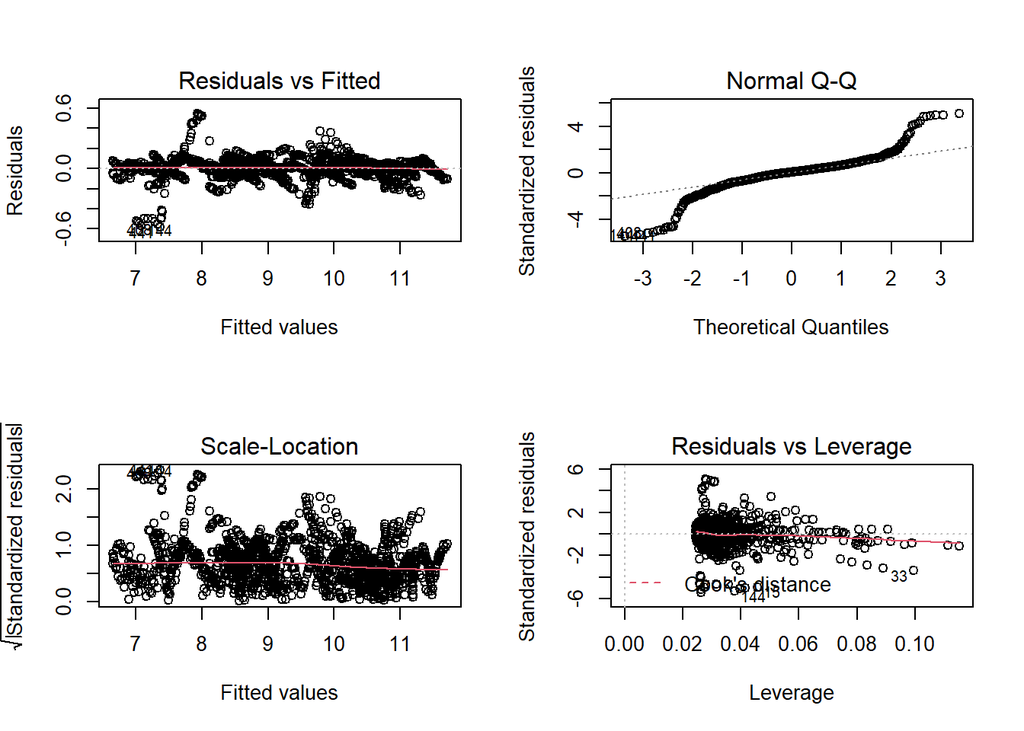

```r
par(mfrow=c(2,2))
plot(fit.lm.log)
```

Al aplicar la función logaritmo sobre la variable el R2 se mantiene alto, sigue estando sobre-ajustado el modelo. A continuación, se presentan los modelos de regresión generalizados.

- Primer modelo GLM: todas las variables

En este caso para estimar la cantidad de recuperados se pone la variable **Recovered** como variable dependiente del modelo. Al tratarse de una variable contadora se fija como familia la Poisson.

```r
fit.glm.poisson.all <- glm(Recovered ~ . - Lat - Long_,
                       family = 'poisson', data=training)
summary(fit.glm.poisson.all)
```

```
##
## Call:
## glm(formula = Recovered ~ . - Lat - Long_, family = "poisson",
##     data = training)
##
## Deviance Residuals:
##     Min       1Q   Median       3Q      Max
## -46.689   -4.153    0.401    4.414   49.035
##
## Coefficients:
##                                Estimate Std. Error  z value Pr(>|z|)
## (Intercept)                  -7.882e+01  1.013e+00  -77.824   <2e-16 ***
## Province_StateArizona        -2.703e-01  4.766e-03  -56.717   <2e-16 ***
## Province_StateArkansas       -1.154e-02  2.220e-03   -5.199    2e-07 ***
## Province_StateColorado       -1.069e+00  3.772e-03 -283.527   <2e-16 ***
## Province_StateConnecticut    -6.517e-01  7.435e-03  -87.654   <2e-16 ***
## Province_StateHawaii         -2.359e+00  5.050e-03 -467.193   <2e-16 ***
## Province_StateIdaho          -1.406e+00  2.988e-03 -470.424   <2e-16 ***
## Province_StateIndiana         6.777e-01  4.078e-03  166.205   <2e-16 ***
## Province_StateKansas         -2.889e+00  4.979e-03 -580.217   <2e-16 ***
## Province_StateKentucky       -7.547e-01  2.870e-03 -262.940   <2e-16 ***
## Province_StateMaine          -1.585e+00  4.187e-03 -378.504   <2e-16 ***
## Province_StateMaryland       -1.111e+00  3.859e-03 -287.776   <2e-16 ***
## Province_StateMassachusetts   1.230e+00  1.156e-02  106.348   <2e-16 ***
## Province_StateMinnesota       5.318e-01  2.851e-03  186.502   <2e-16 ***
## Province_StateMississippi    -1.743e-01  2.877e-03  -60.576   <2e-16 ***
## Province_StateMontana        -1.941e+00  4.157e-03 -467.001   <2e-16 ***
## Province_StateNebraska       -4.849e-01  2.390e-03 -202.874   <2e-16 ***
## Province_StateNew Hampshire  -1.500e+00  6.919e-03 -216.797   <2e-16 ***
## Province_StateNew Jersey      1.775e+00  2.062e-02   86.076   <2e-16 ***
## Province_StateNew Mexico     -7.709e-01  4.021e-03 -191.738   <2e-16 ***
## Province_StateNew York        3.740e+00  4.056e-02   92.213   <2e-16 ***
## Province_StateNorth Dakota   -1.468e+00  3.839e-03 -382.305   <2e-16 ***
## Province_StateOhio            1.068e+00  4.673e-03  228.582   <2e-16 ***
## Province_StateOklahoma        1.610e-01  2.060e-03   78.184   <2e-16 ***
## Province_StateOregon         -1.421e+00  3.489e-03 -407.369   <2e-16 ***
## Province_StateRhode Island   -3.105e+00  5.979e-03 -519.405   <2e-16 ***
## Province_StateSouth Carolina -1.907e-02  2.195e-03   -8.684   <2e-16 ***
## Province_StateSouth Dakota   -1.004e+00  2.943e-03 -341.216   <2e-16 ***
## Province_StateTennessee       4.111e-01  2.491e-03  165.022   <2e-16 ***
```

[output cut: 9 more lines]

```
## People_Hospitalized           5.144e-05  4.466e-07  115.197   <2e-16 ***
## Case_Fatality_Ratio           1.203e-01  1.500e-03   80.206   <2e-16 ***
## Testing_Rate                 -4.416e-06  2.375e-07  -18.588   <2e-16 ***
## Hospitalization_Rate         -6.170e-02  5.365e-04 -115.007   <2e-16 ***
## Date                          4.798e-03  5.494e-05   87.333   <2e-16 ***
## ---
## Signif. codes:  0 '***' 0.001 '**' 0.01 '*' 0.05 '.' 0.1 ' ' 1
##
## (Dispersion parameter for poisson family taken to be 1)
##
##     Null deviance: 33123902  on 1349  degrees of freedom
## Residual deviance:   127562  on 1307  degrees of freedom
## AIC: 142815
##
## Number of Fisher Scoring iterations: 4
```

Aunque un modelo de regresión lineal y un modelo generalizado no se pueden comparar directamente en función de las métricas alcanzadas, se puede afirmar que este modelo ha mejorado teniendo en cuenta la diferencia entre la Null y la Residual deviance.

Analicemos la influencia de los coeficientes,

```r
exp(cbind(coef(fit.glm.poisson.all), confint(fit.glm.poisson.all)))
```

```
##                                                  2.5 %       97.5 %
## (Intercept)                  5.879976e-35 8.076887e-36 4.279704e-34
## Province_StateArizona        7.631486e-01 7.560524e-01 7.703095e-01
## Province_StateArkansas       9.885243e-01 9.842328e-01 9.928353e-01
## Province_StateColorado       3.432251e-01 3.406970e-01 3.457715e-01
## Province_StateConnecticut    5.211438e-01 5.136047e-01 5.287944e-01
## Province_StateHawaii         9.448926e-02 9.355784e-02 9.542829e-02
## Province_StateIdaho          2.452091e-01 2.437771e-01 2.466492e-01
## Province_StateIndiana        1.969385e+00 1.953710e+00 1.985190e+00
## Province_StateKansas         5.562370e-02 5.508285e-02 5.616858e-02
## Province_StateKentucky       4.701730e-01 4.675352e-01 4.728249e-01
## Province_StateMaine          2.049871e-01 2.033114e-01 2.066759e-01
## Province_StateMaryland       3.293934e-01 3.269113e-01 3.318939e-01
## Province_StateMassachusetts  3.420327e+00 3.343688e+00 3.498736e+00
## Province_StateMinnesota      1.702001e+00 1.692517e+00 1.711541e+00
## Province_StateMississippi    8.400682e-01 8.353450e-01 8.448187e-01
## Province_StateMontana        1.435427e-01 1.423776e-01 1.447164e-01
## Province_StateNebraska       6.157750e-01 6.128974e-01 6.186664e-01
## Province_StateNew Hampshire  2.231048e-01 2.200998e-01 2.261515e-01
## Province_StateNew Jersey     5.899929e+00 5.666235e+00 6.143265e+00
## Province_StateNew Mexico     4.625924e-01 4.589614e-01 4.662522e-01
## Province_StateNew York       4.208839e+01 3.887240e+01 4.557049e+01
## Province_StateNorth Dakota   2.304239e-01 2.286964e-01 2.321644e-01
## Province_StateOhio           2.910140e+00 2.883610e+00 2.936921e+00
## Province_StateOklahoma       1.174709e+00 1.169978e+00 1.179461e+00
## Province_StateOregon         2.413729e-01 2.397273e-01 2.430288e-01
## Province_StateRhode Island   4.480798e-02 4.428585e-02 4.533599e-02
## Province_StateSouth Carolina 9.811146e-01 9.769027e-01 9.853461e-01
## Province_StateSouth Dakota   3.663683e-01 3.642611e-01 3.684874e-01
## Province_StateTennessee      1.508514e+00 1.501166e+00 1.515898e+00
## Province_StateUtah           9.206211e-01 9.166957e-01 9.245637e-01
## Province_StateVirginia       7.112926e-01 7.076148e-01 7.149889e-01
## Province_StateWisconsin      1.616734e+00 1.610252e+00 1.623244e+00
## Province_StateWyoming        1.180475e-01 1.170921e-01 1.190095e-01
## Confirmed                    1.000006e+00 1.000006e+00 1.000006e+00
## Deaths                       9.997882e-01 9.997845e-01 9.997919e-01
## Active                       9.999899e-01 9.999899e-01 9.999900e-01
## Incident_Rate                1.000514e+00 1.000509e+00 1.000519e+00
## Total_Test_Results           1.000000e+00 1.000000e+00 1.000000e+00
## People_Hospitalized          1.000051e+00 1.000051e+00 1.000052e+00
## Case_Fatality_Ratio          1.127827e+00 1.124516e+00 1.131147e+00
## Testing_Rate                 9.999956e-01 9.999951e-01 9.999960e-01
## Hospitalization_Rate         9.401644e-01 9.391764e-01 9.411536e-01
## Date                         1.004810e+00 1.004702e+00 1.004918e+00
```

- Modelo GLM: Selección de variables

En este modelo se incluyen interacciones entre las variables. Se propone añadir uun cruce entre las variables Hospitalization_Rate y Confirmed puesto que muchos de los casos confirmados que son hospitalizados pueden resultar en fallecimientos, lo cual influye en la cantidad de recuperados. Asimismo, intuitivamente, se adiciona el cruce entre **Case_Fatality_Ratio** y **Active**. Adicionalmente incluimos la interacción Deaths:Active.

```r
glm.select <- glm(Recovered ~ Hospitalization_Rate*Confirmed + Case_Fatality_Ratio*Active + Deaths:Active + Province_State,
                       family = 'poisson', data=training)

summary(glm.select)
```

```
##
## Call:
## glm(formula = Recovered ~ Hospitalization_Rate * Confirmed +
##     Case_Fatality_Ratio * Active + Deaths:Active + Province_State,
##     family = "poisson", data = training)
##
## Deviance Residuals:
##     Min       1Q   Median       3Q      Max
## -63.674   -5.865   -0.062    5.609   59.410
##
## Coefficients:
##                                  Estimate Std. Error  z value Pr(>|z|)
## (Intercept)                     9.918e+00  3.462e-03 2864.761  < 2e-16 ***
## Hospitalization_Rate           -8.346e-02  4.784e-04 -174.455  < 2e-16 ***
## Confirmed                       1.432e-05  3.025e-08  473.255  < 2e-16 ***
## Case_Fatality_Ratio             1.002e-01  1.227e-03   81.640  < 2e-16 ***
## Active                         -8.935e-06  7.214e-08 -123.864  < 2e-16 ***
## Province_StateArizona          -1.170e+00  3.955e-03 -295.715  < 2e-16 ***
## Province_StateArkansas          2.772e-01  2.034e-03  136.304  < 2e-16 ***
## Province_StateColorado         -1.198e+00  3.367e-03 -355.744  < 2e-16 ***
## Province_StateConnecticut      -8.288e-01  7.766e-03 -106.728  < 2e-16 ***
## Province_StateHawaii           -2.200e+00  4.801e-03 -458.197  < 2e-16 ***
## Province_StateIdaho            -1.066e+00  2.864e-03 -372.301  < 2e-16 ***
## Province_StateIndiana           2.881e-01  3.047e-03   94.555  < 2e-16 ***
## Province_StateKansas           -2.699e+00  4.861e-03 -555.191  < 2e-16 ***
## Province_StateKentucky         -6.544e-01  2.386e-03 -274.259  < 2e-16 ***
## Province_StateMaine            -1.361e+00  3.319e-03 -409.985  < 2e-16 ***
## Province_StateMaryland         -1.601e+00  4.845e-03 -330.515  < 2e-16 ***
## Province_StateMassachusetts    -4.321e-01  7.382e-03  -58.538  < 2e-16 ***
## Province_StateMinnesota         3.599e-01  2.412e-03  149.218  < 2e-16 ***
## Province_StateMississippi       8.768e-02  2.487e-03   35.256  < 2e-16 ***
## Province_StateMontana          -1.780e+00  3.754e-03 -474.282  < 2e-16 ***
## Province_StateNebraska         -5.792e-02  2.181e-03  -26.554  < 2e-16 ***
## Province_StateNew Hampshire    -1.202e+00  5.281e-03 -227.651  < 2e-16 ***
## Province_StateNew Jersey       -1.515e+00  2.300e-02  -65.871  < 2e-16 ***
## Province_StateNew Mexico       -4.473e-01  2.550e-03 -175.416  < 2e-16 ***
## Province_StateNew York         -2.772e+00  4.273e-02  -64.861  < 2e-16 ***
## Province_StateNorth Dakota     -1.103e+00  3.046e-03 -362.288  < 2e-16 ***
## Province_StateOhio              1.478e-01  3.105e-03   47.618  < 2e-16 ***
## Province_StateOklahoma          3.071e-01  1.985e-03  154.730  < 2e-16 ***
## Province_StateOregon           -1.334e+00  3.016e-03 -442.473  < 2e-16 ***
## Province_StateRhode Island     -2.214e+00  4.959e-03 -446.539  < 2e-16 ***
## Province_StateSouth Carolina   -2.331e-01  2.012e-03 -115.866  < 2e-16 ***
## Province_StateSouth Dakota     -4.819e-01  2.732e-03 -176.398  < 2e-16 ***
## Province_StateTennessee         6.375e-03  1.802e-03    3.538 0.000403 ***
## Province_StateUtah              1.546e-01  2.074e-03   74.524  < 2e-16 ***
## Province_StateVirginia         -8.068e-01  2.139e-03 -377.253  < 2e-16 ***
## Province_StateWisconsin         3.992e-01  1.882e-03  212.097  < 2e-16 ***
## Province_StateWyoming          -1.888e+00  4.021e-03 -469.491  < 2e-16 ***
## Hospitalization_Rate:Confirmed  4.558e-07  3.754e-09  121.421  < 2e-16 ***
## Case_Fatality_Ratio:Active      1.944e-07  2.891e-08    6.722 1.79e-11 ***
## Active:Deaths                  -2.652e-10  2.325e-12 -114.072  < 2e-16 ***
## ---
## Signif. codes:  0 '***' 0.001 '**' 0.01 '*' 0.05 '.' 0.1 ' ' 1
##
## (Dispersion parameter for poisson family taken to be 1)
##
##     Null deviance: 33123902  on 1349  degrees of freedom
## Residual deviance:   300971  on 1310  degrees of freedom
## AIC: 316218
##
## Number of Fisher Scoring iterations: 4
```

Todas las variables tienen un p-valor muy pequeño por lo tanto influyen en la estimación de la variable objetivo. Aunque este modelo no obtiene mejor AIC que el modelo completo, sí reduce la deviance. Veamos cuánto influyen numéricamente en la variable objetivo. Invetimos el link, como el link es el logaritmo tomamos la exponencial.

```r
exp(cbind(coef(glm.select), confint(glm.select)))
```

```
##                                                    2.5 %       97.5 %
## (Intercept)                    2.029608e+04 2.015879e+04 2.043424e+04
## Hospitalization_Rate           9.199304e-01 9.190683e-01 9.207935e-01
## Confirmed                      1.000014e+00 1.000014e+00 1.000014e+00
## Case_Fatality_Ratio            1.105375e+00 1.102719e+00 1.108037e+00
## Active                         9.999911e-01 9.999909e-01 9.999912e-01
## Province_StateArizona          3.105006e-01 3.081027e-01 3.129166e-01
## Province_StateArkansas         1.319474e+00 1.314226e+00 1.324746e+00
## Province_StateColorado         3.018592e-01 2.998734e-01 3.038575e-01
## Province_StateConnecticut      4.365683e-01 4.299742e-01 4.432642e-01
## Province_StateHawaii           1.108246e-01 1.097856e-01 1.118713e-01
## Province_StateIdaho            3.442935e-01 3.423661e-01 3.462314e-01
## Province_StateIndiana          1.333947e+00 1.326005e+00 1.341939e+00
## Province_StateKansas           6.728167e-02 6.664288e-02 6.792496e-02
## Province_StateKentucky         5.197708e-01 5.173453e-01 5.222066e-01
## Province_StateMaine            2.564703e-01 2.548066e-01 2.581434e-01
## Province_StateMaryland         2.016397e-01 1.997340e-01 2.035634e-01
## Province_StateMassachusetts    6.491147e-01 6.397916e-01 6.585764e-01
## Province_StateMinnesota        1.433120e+00 1.426363e+00 1.439911e+00
## Province_StateMississippi      1.091637e+00 1.086331e+00 1.096973e+00
## Province_StateMontana          1.685752e-01 1.673388e-01 1.698194e-01
## Province_StateNebraska         9.437245e-01 9.396990e-01 9.477681e-01
## Province_StateNew Hampshire    3.005382e-01 2.974439e-01 3.036653e-01
## Province_StateNew Jersey       2.197960e-01 2.101080e-01 2.299315e-01
## Province_StateNew Mexico       6.393722e-01 6.361845e-01 6.425750e-01
## Province_StateNew York         6.256426e-02 5.753808e-02 6.803007e-02
## Province_StateNorth Dakota     3.317578e-01 3.297832e-01 3.337438e-01
## Province_StateOhio             1.159324e+00 1.152292e+00 1.166401e+00
## Province_StateOklahoma         1.359532e+00 1.354253e+00 1.364832e+00
## Province_StateOregon           2.633286e-01 2.617760e-01 2.648888e-01
## Province_StateRhode Island     1.092397e-01 1.081827e-01 1.103061e-01
## Province_StateSouth Carolina   7.920973e-01 7.889809e-01 7.952267e-01
## Province_StateSouth Dakota     6.176140e-01 6.143156e-01 6.209294e-01
## Province_StateTennessee        1.006395e+00 1.002848e+00 1.009956e+00
## Province_StateUtah             1.167143e+00 1.162409e+00 1.171898e+00
## Province_StateVirginia         4.462695e-01 4.444025e-01 4.481438e-01
## Province_StateWisconsin        1.490580e+00 1.485092e+00 1.496089e+00
## Province_StateWyoming          1.514071e-01 1.502178e-01 1.526042e-01
## Hospitalization_Rate:Confirmed 1.000000e+00 1.000000e+00 1.000000e+00
## Case_Fatality_Ratio:Active     1.000000e+00 1.000000e+00 1.000000e+00
## Active:Deaths                  1.000000e+00 1.000000e+00 1.000000e+00
```

Todos los coeficientes producto de las interacciones añadidas son muy similares y cercanos a 1.

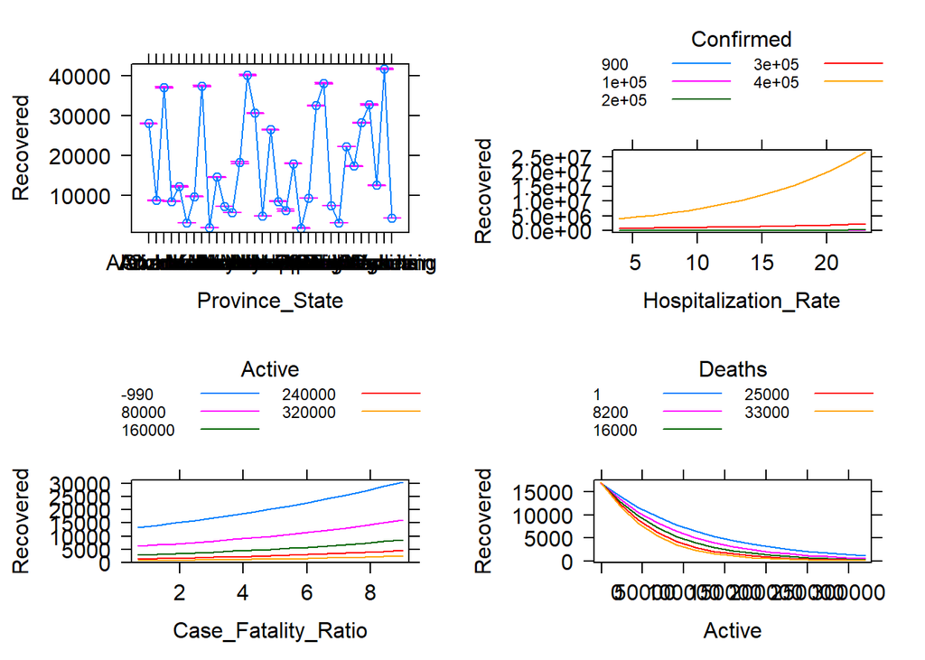

```r
plot(allEffects(glm.select), rescale.axis=FALSE, multiline=TRUE, rug=FALSE, main="")
```

```
## NOTE: Active is not a high-order term in the model
```

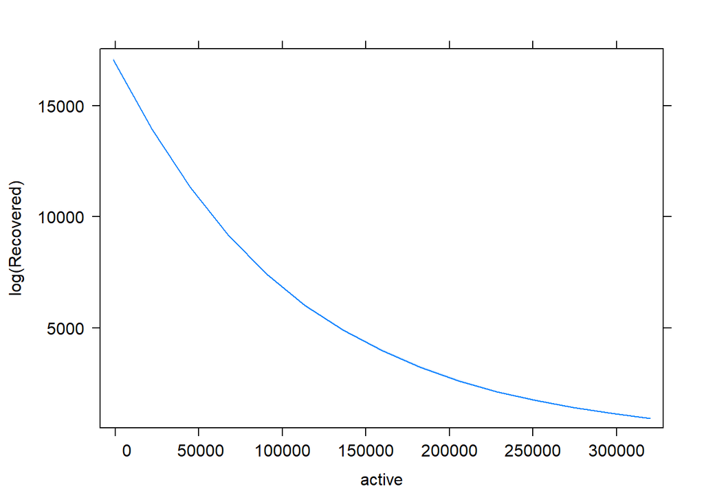

```r
plot(effect("Active", glm.select), ci.style="band", rescale.axis=FALSE, multiline=TRUE, xlab="active", ylab="log(Recovered)", rug=FALSE, main="")
```

```
## NOTE: Confirmed is not a high-order term in the model
```

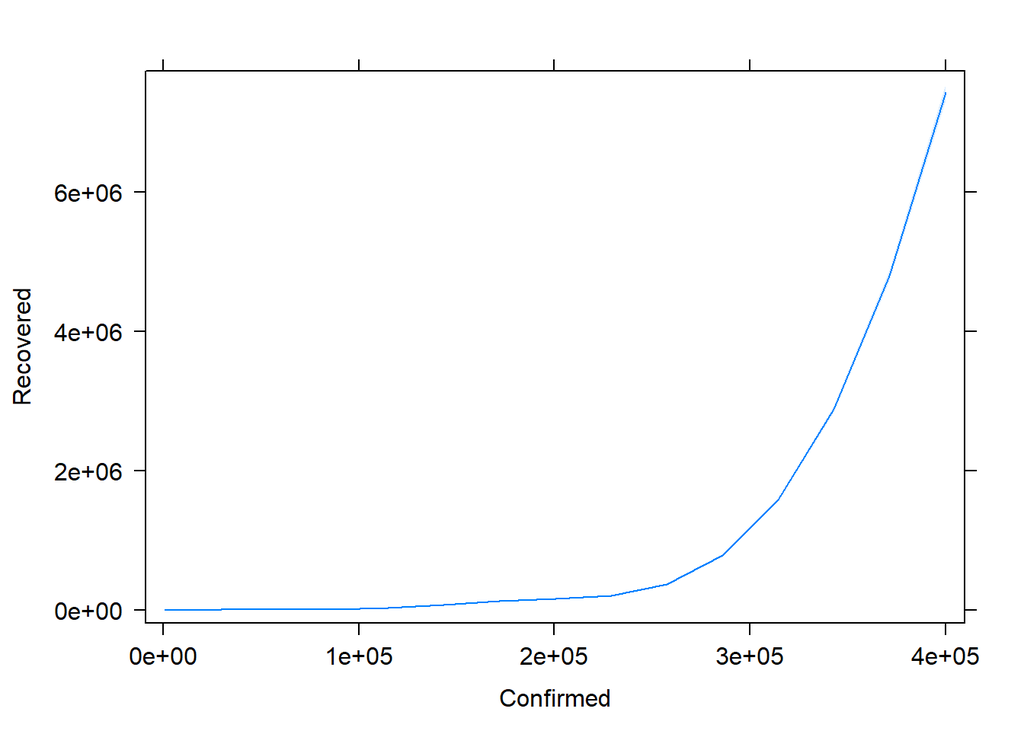

```r
plot(effect("Confirmed", glm.select), ci.style="band", rescale.axis=FALSE, multiline=TRUE, xlab="Confirmed", ylab="Recovered", rug=FALSE, main="")
```

Así mismo ocurre con los casos confirmados al aplicar la transformación de la variable objetivo.

- Modelo GLM QuasiPoisson

El modelo de Poisson asume que la varianza y la media de los datos son iguales. Sin embargo, en la práctica generalemnte existe diferencia. A esto se le conoce como sobredispersión e implicaría en este caso que la varianza de la cantidad de recuperados es mayor que lo que asume el modelo de Poisson. Para modelar esto se puede utilizar el modelo quassi-poisson o la binomial negativa.

```r
glm.select.qp <- glm(Recovered ~ Hospitalization_Rate*Confirmed +
                       Case_Fatality_Ratio*Active + Deaths:Active + Province_State,
                       family = 'quasipoisson', data=training)
summary(glm.select.qp)
```

```
##
## Call:
## glm(formula = Recovered ~ Hospitalization_Rate * Confirmed +
##     Case_Fatality_Ratio * Active + Deaths:Active + Province_State,
##     family = "quasipoisson", data = training)
##
## Deviance Residuals:
##     Min       1Q   Median       3Q      Max
## -63.674   -5.865   -0.062    5.609   59.410
##
## Coefficients:
##                                  Estimate Std. Error t value Pr(>|t|)
## (Intercept)                     9.918e+00  5.192e-02 191.017  < 2e-16 ***
## Hospitalization_Rate           -8.346e-02  7.175e-03 -11.632  < 2e-16 ***
## Confirmed                       1.432e-05  4.537e-07  31.556  < 2e-16 ***
## Case_Fatality_Ratio             1.002e-01  1.840e-02   5.444 6.23e-08 ***
## Active                         -8.935e-06  1.082e-06  -8.259 3.55e-16 ***
## Province_StateArizona          -1.170e+00  5.932e-02 -19.718  < 2e-16 ***
## Province_StateArkansas          2.772e-01  3.050e-02   9.089  < 2e-16 ***
## Province_StateColorado         -1.198e+00  5.050e-02 -23.720  < 2e-16 ***
## Province_StateConnecticut      -8.288e-01  1.165e-01  -7.116 1.82e-12 ***
## Province_StateHawaii           -2.200e+00  7.200e-02 -30.552  < 2e-16 ***
## Province_StateIdaho            -1.066e+00  4.295e-02 -24.824  < 2e-16 ***
## Province_StateIndiana           2.881e-01  4.570e-02   6.305 3.94e-10 ***
## Province_StateKansas           -2.699e+00  7.290e-02 -37.019  < 2e-16 ***
## Province_StateKentucky         -6.544e-01  3.578e-02 -18.287  < 2e-16 ***
## Province_StateMaine            -1.361e+00  4.978e-02 -27.337  < 2e-16 ***
## Province_StateMaryland         -1.601e+00  7.266e-02 -22.038  < 2e-16 ***
## Province_StateMassachusetts    -4.321e-01  1.107e-01  -3.903 9.98e-05 ***
## Province_StateMinnesota         3.599e-01  3.617e-02   9.950  < 2e-16 ***
## Province_StateMississippi       8.768e-02  3.730e-02   2.351  0.01888 *
## Province_StateMontana          -1.780e+00  5.630e-02 -31.624  < 2e-16 ***
## Province_StateNebraska         -5.792e-02  3.271e-02  -1.771  0.07686 .
## Province_StateNew Hampshire    -1.202e+00  7.920e-02 -15.179  < 2e-16 ***
## Province_StateNew Jersey       -1.515e+00  3.449e-01  -4.392 1.21e-05 ***
## Province_StateNew Mexico       -4.473e-01  3.824e-02 -11.696  < 2e-16 ***
## Province_StateNew York         -2.772e+00  6.409e-01  -4.325 1.64e-05 ***
## Province_StateNorth Dakota     -1.103e+00  4.567e-02 -24.157  < 2e-16 ***
## Province_StateOhio              1.478e-01  4.656e-02   3.175  0.00153 **
## Province_StateOklahoma          3.071e-01  2.977e-02  10.317  < 2e-16 ***
## Province_StateOregon           -1.334e+00  4.523e-02 -29.503  < 2e-16 ***
## Province_StateRhode Island     -2.214e+00  7.437e-02 -29.774  < 2e-16 ***
## Province_StateSouth Carolina   -2.331e-01  3.017e-02  -7.726 2.20e-14 ***
## Province_StateSouth Dakota     -4.819e-01  4.097e-02 -11.762  < 2e-16 ***
## Province_StateTennessee         6.375e-03  2.702e-02   0.236  0.81354
## Province_StateUtah              1.546e-01  3.110e-02   4.969 7.62e-07 ***
## Province_StateVirginia         -8.068e-01  3.208e-02 -25.154  < 2e-16 ***
## Province_StateWisconsin         3.992e-01  2.823e-02  14.142  < 2e-16 ***
## Province_StateWyoming          -1.888e+00  6.030e-02 -31.305  < 2e-16 ***
## Hospitalization_Rate:Confirmed  4.558e-07  5.630e-08   8.096 1.29e-15 ***
## Case_Fatality_Ratio:Active      1.944e-07  4.336e-07   0.448  0.65406
## Active:Deaths                  -2.652e-10  3.487e-11  -7.606 5.37e-14 ***
## ---
## Signif. codes:  0 '***' 0.001 '**' 0.01 '*' 0.05 '.' 0.1 ' ' 1
##
## (Dispersion parameter for quasipoisson family taken to be 224.9227)
##
##     Null deviance: 33123902  on 1349  degrees of freedom
## Residual deviance:   300971  on 1310  degrees of freedom
## AIC: NA
##
## Number of Fisher Scoring iterations: 4
```

```r
exp(cbind(coef(glm.select.qp), confint(glm.select.qp)))
```

```
##                                                    2.5 %       97.5 %
## (Intercept)                    2.029608e+04 1.832615e+04 2.246297e+04
## Hospitalization_Rate           9.199304e-01 9.070984e-01 9.329722e-01
## Confirmed                      1.000014e+00 1.000013e+00 1.000015e+00
## Case_Fatality_Ratio            1.105375e+00 1.066178e+00 1.145938e+00
## Active                         9.999911e-01 9.999889e-01 9.999932e-01
## Province_StateArizona          3.105006e-01 2.763698e-01 3.487146e-01
## Province_StateArkansas         1.319474e+00 1.243063e+00 1.400954e+00
## Province_StateColorado         3.018592e-01 2.733513e-01 3.331894e-01
## Province_StateConnecticut      4.365683e-01 3.475315e-01 5.486125e-01
## Province_StateHawaii           1.108246e-01 9.602372e-02 1.273526e-01
## Province_StateIdaho            3.442935e-01 3.164628e-01 3.744981e-01
## Province_StateIndiana          1.333947e+00 1.219846e+00 1.459183e+00
## Province_StateKansas           6.728167e-02 5.816241e-02 7.741364e-02
## Province_StateKentucky         5.197708e-01 4.844386e-01 5.573904e-01
## Province_StateMaine            2.564703e-01 2.324817e-01 2.825804e-01
## Province_StateMaryland         2.016397e-01 1.748600e-01 2.324811e-01
## Province_StateMassachusetts    6.491147e-01 5.227313e-01 8.067952e-01
## Province_StateMinnesota        1.433120e+00 1.335323e+00 1.538720e+00
## Province_StateMississippi      1.091637e+00 1.015003e+00 1.174797e+00
## Province_StateMontana          1.685752e-01 1.508190e-01 1.880702e-01
## Province_StateNebraska         9.437245e-01 8.852134e-01 1.006329e+00
## Province_StateNew Hampshire    3.005382e-01 2.573800e-01 3.510796e-01
## Province_StateNew Jersey       2.197960e-01 1.118291e-01 4.323125e-01
## Province_StateNew Mexico       6.393722e-01 5.931123e-01 6.890321e-01
## Province_StateNew York         6.256426e-02 1.783333e-02 2.199076e-01
## Province_StateNorth Dakota     3.317578e-01 3.033070e-01 3.627825e-01
## Province_StateOhio             1.159324e+00 1.058392e+00 1.270324e+00
## Province_StateOklahoma         1.359532e+00 1.282600e+00 1.441361e+00
## Province_StateOregon           2.633286e-01 2.408305e-01 2.875529e-01
## Province_StateRhode Island     1.092397e-01 9.433516e-02 1.262708e-01
## Province_StateSouth Carolina   7.920973e-01 7.467015e-01 8.404399e-01
## Province_StateSouth Dakota     6.176140e-01 5.698955e-01 6.691857e-01
## Province_StateTennessee        1.006395e+00 9.545444e-01 1.061204e+00
## Province_StateUtah             1.167143e+00 1.098206e+00 1.240614e+00
## Province_StateVirginia         4.462695e-01 4.190229e-01 4.751644e-01
## Province_StateWisconsin        1.490580e+00 1.410536e+00 1.575562e+00
## Province_StateWyoming          1.514071e-01 1.343719e-01 1.702136e-01
## Hospitalization_Rate:Confirmed 1.000000e+00 1.000000e+00 1.000001e+00
## Case_Fatality_Ratio:Active     1.000000e+00 9.999993e-01 1.000001e+00
## Active:Deaths                  1.000000e+00 1.000000e+00 1.000000e+00
```

Los coeficientes son bastante parecidos a los del modelo de poisson, sin embargo, obtenemos coeficientes más limpios y fáciles de interpretar. Aunque no se puede medir exactamente la mejora de este modelo sobre el quasi-poisson, se recomienda utilzar este porque ha sido modelado teniendo en cuenta la sobre-dispersión de los datos, mientras que el de poissson ajusta los coeficientes asumiendo algo que no se cumple.

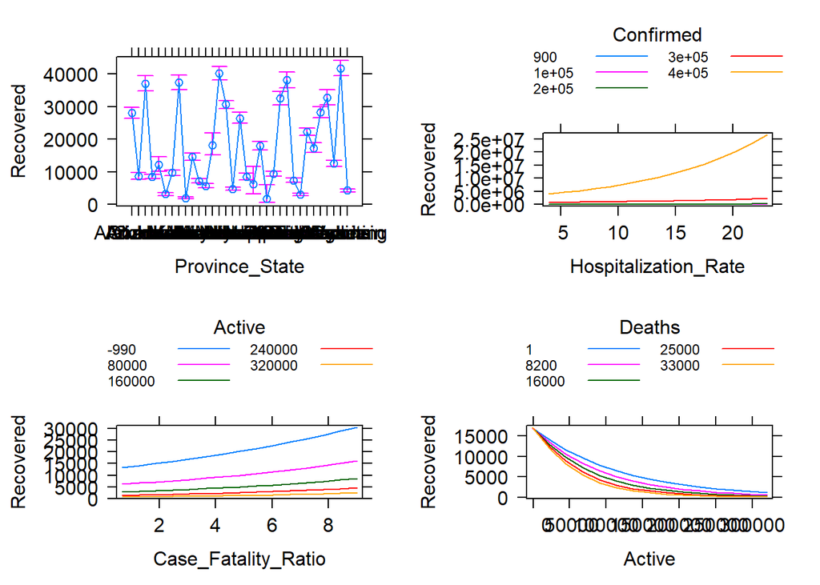

```r
plot(allEffects(glm.select.qp), rescale.axis=FALSE, multiline=TRUE, rug=FALSE, main="")
```

```
## NOTE: Active is not a high-order term in the model
```

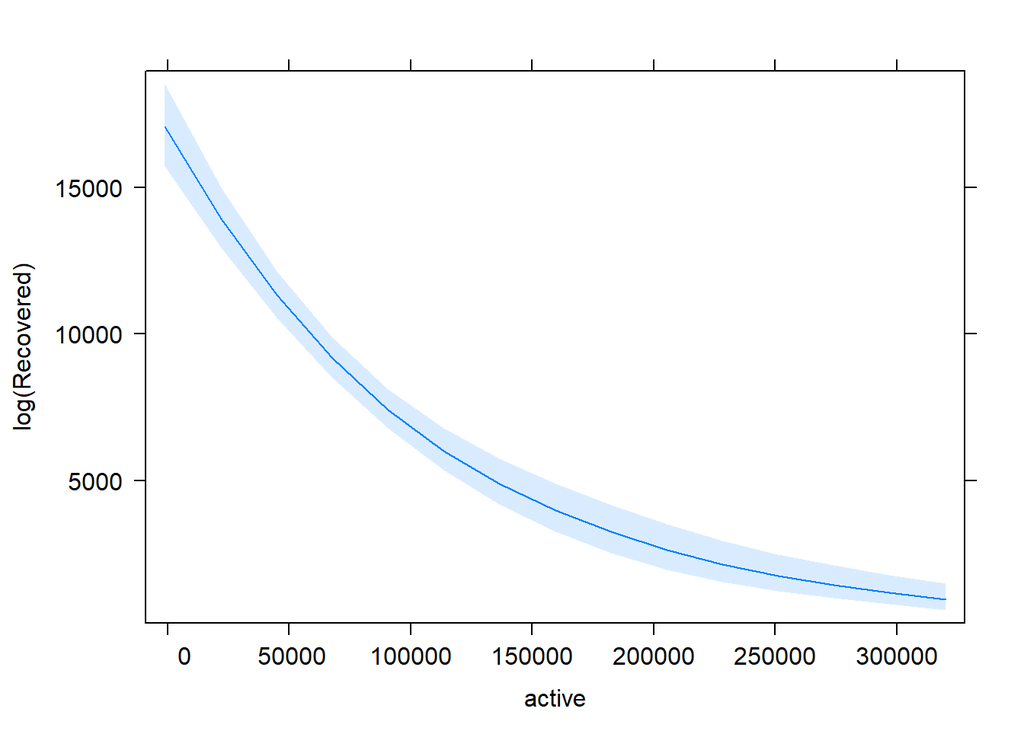

```r
plot(effect("Active", glm.select.qp), ci.style="band", rescale.axis=FALSE, multiline=TRUE, xlab="active", ylab="log(Recovered)", rug=FALSE, main="")
```

```
## NOTE: Confirmed is not a high-order term in the model
```

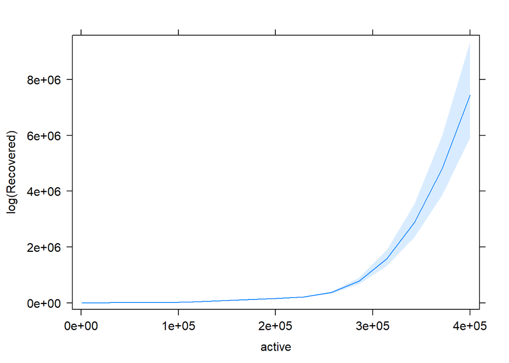

```r
plot(effect("Confirmed", glm.select.qp), ci.style="band", rescale.axis=FALSE, multiline=TRUE, xlab="active", ylab="log(Recovered)", rug=FALSE, main="")
```

La relación existente entre las variables es clara y permanece al utilizar el modelo de quasi-poisson. Intentemos con la binomial negativa.

- Modelo Binomial negativa

```r
glm.select.nb <- glm.nb(Recovered ~ Hospitalization_Rate*Confirmed +
                       Case_Fatality_Ratio*Active + Deaths:Active + Province_State,
                       data=training)
summary(glm.select.nb)
```

```
##
## Call:
## glm.nb(formula = Recovered ~ Hospitalization_Rate * Confirmed +
##     Case_Fatality_Ratio * Active + Deaths:Active + Province_State,
##     data = training, init.theta = 38.82948776, link = log)
##
## Deviance Residuals:
##     Min       1Q   Median       3Q      Max
## -4.7560  -0.3871  -0.0075   0.3488   4.6690
##
## Coefficients:
##                                  Estimate Std. Error z value Pr(>|z|)
## (Intercept)                     1.032e+01  7.567e-02 136.326  < 2e-16 ***
## Hospitalization_Rate           -1.420e-01  9.199e-03 -15.438  < 2e-16 ***
## Confirmed                       1.460e-05  8.062e-07  18.109  < 2e-16 ***
## Case_Fatality_Ratio             1.476e-01  3.019e-02   4.889 1.01e-06 ***
## Active                         -1.216e-05  1.838e-06  -6.614 3.74e-11 ***
## Province_StateArizona          -1.267e+00  9.557e-02 -13.253  < 2e-16 ***
## Province_StateArkansas          1.139e-01  5.119e-02   2.225 0.026059 *
## Province_StateColorado         -1.070e+00  7.758e-02 -13.787  < 2e-16 ***
## Province_StateConnecticut      -6.745e-01  2.049e-01  -3.291 0.000998 ***
## Province_StateHawaii           -2.192e+00  5.732e-02 -38.246  < 2e-16 ***
## Province_StateIdaho            -1.299e+00  5.571e-02 -23.315  < 2e-16 ***
## Province_StateIndiana           2.227e-01  7.649e-02   2.911 0.003598 **
## Province_StateKansas           -2.779e+00  4.850e-02 -57.292  < 2e-16 ***
## Province_StateKentucky         -5.092e-01  4.546e-02 -11.202  < 2e-16 ***
## Province_StateMaine            -1.337e+00  5.221e-02 -25.600  < 2e-16 ***
## Province_StateMaryland         -1.551e+00  1.349e-01 -11.496  < 2e-16 ***
## Province_StateMassachusetts    -9.442e-01  1.811e-01  -5.215 1.84e-07 ***
## Province_StateMinnesota         2.225e-01  6.104e-02   3.646 0.000267 ***
## Province_StateMississippi      -9.713e-02  5.948e-02  -1.633 0.102461
## Province_StateMontana          -1.939e+00  5.492e-02 -35.306  < 2e-16 ***
## Province_StateNebraska         -1.895e-01  5.138e-02  -3.688 0.000226 ***
## Province_StateNew Hampshire    -1.316e+00  1.222e-01 -10.766  < 2e-16 ***
## Province_StateNew Jersey       -2.099e+00  6.790e-01  -3.092 0.001991 **
## Province_StateNew Mexico       -2.848e-01  4.725e-02  -6.027 1.67e-09 ***
## Province_StateNew York         -4.038e+00  1.176e+00  -3.433 0.000596 ***
## Province_StateNorth Dakota     -1.269e+00  5.678e-02 -22.348  < 2e-16 ***
## Province_StateOhio              1.708e-02  7.777e-02   0.220 0.826214
## Province_StateOklahoma          2.255e-01  4.795e-02   4.704 2.55e-06 ***
```

[output cut: 13 more lines]

```
## Signif. codes:  0 '***' 0.001 '**' 0.01 '*' 0.05 '.' 0.1 ' ' 1
##
## (Dispersion parameter for Negative Binomial(38.8295) family taken to be 1)
##
##     Null deviance: 71747.1  on 1349  degrees of freedom
## Residual deviance:  1363.2  on 1310  degrees of freedom
## AIC: 24373
##
## Number of Fisher Scoring iterations: 1
##
##
##               Theta:  38.83
##           Std. Err.:  1.51
##
##  2 x log-likelihood:  -24291.15
```

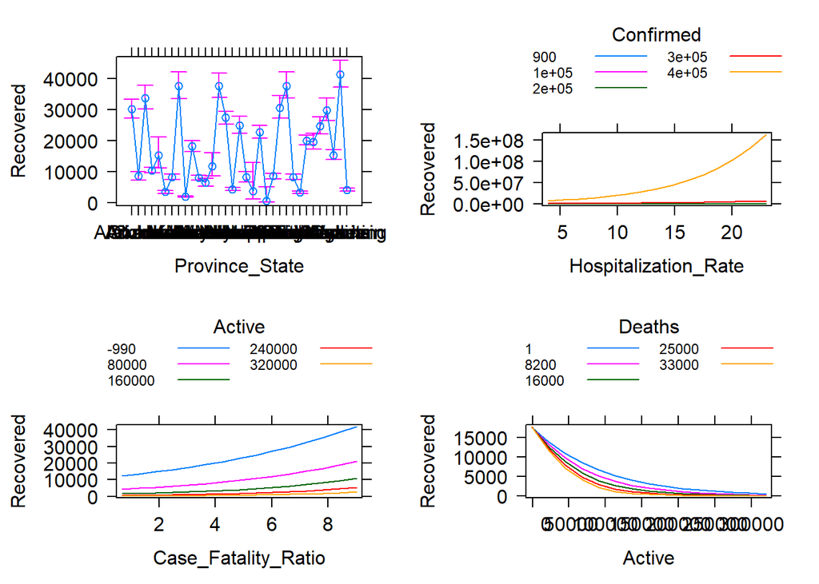

```r
plot(allEffects(glm.select.nb), rescale.axis=FALSE, multiline=TRUE, rug=FALSE, main="")
```

La relación entre las variables se mantiene sin observarse diferencias notables respecto al modelo de quasi-poisson.

## Predicción

En esta sección evaluaremos los dos modelos anteriores, **glm.select.qp** y **glm.select.nb**, que tienen en cuenta el factor de sobre-dispersión. Como teniendo en cuenta el análisis anterior no hay un ganador por excelencia, evaluaremos ambos modelos sobre las predicciones y seleccionamos el de menor error.

- Predicción del modelo de quasi-poisson* **glm.select.qp**

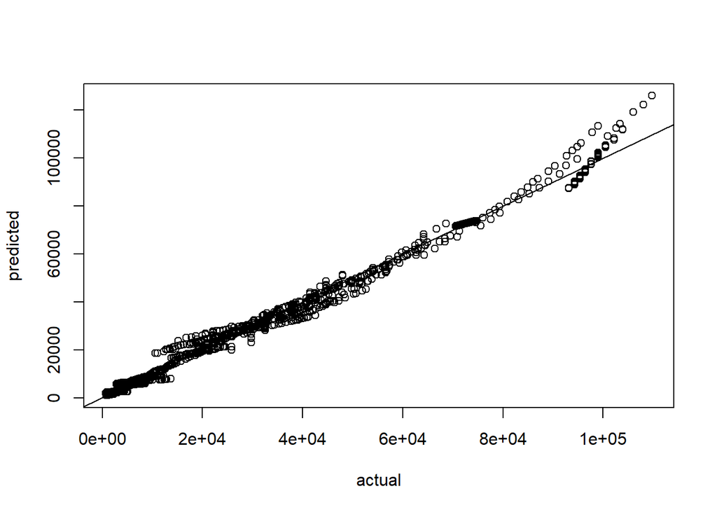

```r
plot(training$Recovered, predict(glm.select.qp, type = "response"),
     xlab="actual",ylab="predicted")
abline(a=0,b=1)
```

```r
cor(training$Confirmed,predict(glm.select.qp, type = "response"))^2
```

```
## [1] 0.3668702
```

```r
predictions = round(predict(glm.select.qp, newdata=testing, type = "response"), digits=0)
head(predictions,20)
```

```
##     2     7     8     9    12    18    19    23    25    26    32    34    42
## 10354  5726 33071   997  4402 29215  6605  2853 17029  7117 25610 24187  3119
##    49    52    55    60    62    63    66
## 29335  5219  2913 20373 25244  1888 24320
```

Intervalos de confianza

```r
preds = predict(glm.select.qp, newdata=testing, type = "link", se.fit=T)
critval <- 1.96 ## approx 95% CI
upr <- preds$fit + (critval * preds$se.fit)
lwr <- preds$fit - (critval * preds$se.fit)
fit <- preds$fit # these predictions are in log-scale

fit2 <- glm.select.qp$family$linkinv(fit)
upr2 <- glm.select.qp$family$linkinv(upr)
lwr2 <- glm.select.qp$family$linkinv(lwr)

data.frame(lower=lwr2, prediction=round(fit2,digits=0), upper=upr2)[1:10,]
```

```
##         lower prediction     upper
## 2   9704.8430      10354 11046.470
## 7   5400.4571       5726  6070.920
## 8  31960.5398      33071 34220.494
## 9    869.6793        997  1142.060
## 12  4121.0751       4402  4701.721
## 18 28218.1890      29215 30246.261
## 19  6253.1858       6605  6975.800
## 23  2632.2061       2853  3091.577
## 25 16295.1330      17029 17796.036
## 26  6748.3584       7117  7505.438
```

Evaluando el poder predictivo del modelo:

```r
# But how can we guess the predictive power of the models?
train <- sample(1:nrow(training), round(nrow(training)*0.80,0))
covid.train <- training[train,]
covid.test <- training[-train,]

fit.qpoisson <- glm(Recovered ~ Hospitalization_Rate * Confirmed +
    Case_Fatality_Ratio * Active + Deaths:Active + Province_State, family = "poisson", data = covid.train)

pred = predict(fit.qpoisson, newdata=covid.test, type = "response")

rmse = sqrt(mean((pred - covid.test$Recovered)^2))
rmse
```

```
## [1] 2436.455
```

```r
sd(covid.test$Recovered)
```

```
## [1] 23612
```

```r
cor(pred, covid.test$Recovered)^2
```

```
## [1] 0.9894122
```

- Predicción del modelo binomial negativa

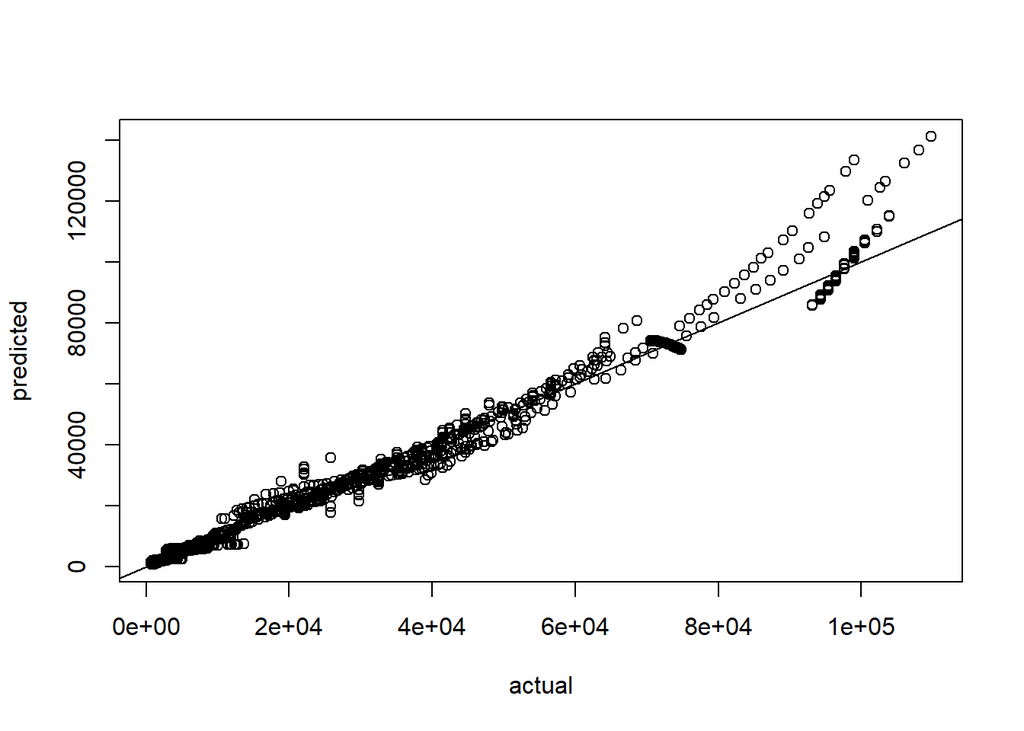

```r
plot(training$Recovered, predict(glm.select.nb, type = "response"),
     xlab="actual",ylab="predicted")
abline(a=0,b=1)
```

```r
cor(training$Confirmed,predict(glm.select.nb, type = "response"))^2
```

```
## [1] 0.3504477
```

```r
predictions = round(predict(glm.select.nb, newdata=testing, type = "response"), digits=0)
head(predictions,20)
```

```
##     2     7     8     9    12    18    19    23    25    26    32    34    42
## 10673  5368 30204   951  4203 28850  5930  2484 15631  6788 29885 22648  2991
##    49    52    55    60    62    63    66
## 28980  5053  2572 18666 21687  1729 22754
```

Intervalos de confianza

```r
preds = predict(glm.select.nb, newdata=testing, type = "link", se.fit=T)
critval <- 1.96 ## approx 95% CI
upr <- preds$fit + (critval * preds$se.fit)
lwr <- preds$fit - (critval * preds$se.fit)
fit <- preds$fit # these predictions are in log-scale

fit2 <- glm.select.nb$family$linkinv(fit)
upr2 <- glm.select.nb$family$linkinv(upr)
lwr2 <- glm.select.nb$family$linkinv(lwr)

data.frame(lower=lwr2, prediction=round(fit2,digits=0), upper=upr2)[1:10,]
```

```
##         lower prediction     upper
## 2   9717.0943      10673 11721.979
## 7   5085.2325       5368  5667.145
## 8  28259.3842      30204 32281.566
## 9    898.9672        951  1005.557
## 12  3969.1712       4203  4450.590
## 18 26967.8345      28850 30862.745
## 19  5610.5437       5930  6268.633
## 23  2344.3539       2484  2631.064
## 25 14567.9206      15631 16771.933
## 26  6446.3887       6788  7146.803
```

Evaluando el poder predictivo del modelo:

```r
fit.nb <- glm.nb(Recovered ~ Hospitalization_Rate * Confirmed +
    Case_Fatality_Ratio * Active + Deaths:Active + Province_State, data = covid.train)

pred = predict(fit.nb, newdata=covid.test, type = "response")

rmse = sqrt(mean((pred - covid.test$Recovered)^2))
rmse
```

```
## [1] 3337.475
```

```r
sd(covid.test$Recovered)
```

```
## [1] 23612
```

```r
cor(pred, covid.test$Recovered)^2
```

```
## [1] 0.9815012
```

Al analizar los gráficos de plot se puede observar que en ambos casos los valores predichos están muy cercanos a los valores reales. La distancia de los puntos a la línea X = Y es pequeña, aunque en el caso del modelo binomial negativo se observa más dispersión. Esta dispersión sugiere que el modelo quasi-poisson predice con menor error.

## Conclusiones

En este trabajo se ha realizado una estimación de la cantidad de casos recuperados diarios. Se ha llegado a la conclusión que esta variable está influenciada por la cantidad de casos confirmados y activos. Se han desarrollado un conjunto de modelos lineales y generalizados. Sin embargo, se pudo apreciar que este tipo de modelos no son los más adecuados para este tipo de problemas, aún cuando logran predecir bien si tienen enn cuenta muchas variables. El análisis no es preciso porque no tiene en cuenta la temporalidad de los datos y las diferencias entre los diferentes estados. Por lo tanto, se recomienda para trabajo futuros incorporar sensibilidad temporal y hacer un análisis más exhaustivo teniendo en cuenta las diferencias de un estado a otro.

## Bibliografía

- https://apps.who.int/iris/bitstream/handle/10665/333857/WHO-2019-nCoV-Sci_Brief-Mortality-2020.1-spa.pdf
- https://stats.idre.ucla.edu/r/dae/negative-binomial-regression/